# Fintech

← Back to overview

## Fintech

### Scope

Products about financial data and money flows — market data and trading simulation, budgeting, payments and settlement sandboxes, fraud monitoring. Precision, high-frequency data handling and auditability are the signature engineering demands.

### Examples

1. **Stock-trading simulator** — live or replayed market data feed, C++ pricing/portfolio engine, real-time custom-rendered charts, leaderboards in Firebase. *References:*
   - [TradingView Paper Trading](https://www.tradingview.com/support/solutions/43000516466-paper-trading-main-functionality/)
   - [Paper trading tutorial (YouTube)](https://www.youtube.com/watch?v=_rfDTsIma8w)
2. **Personal budget tracker with forecasting** — C++ engine simulates future balances from spending patterns; custom chart renderer; category rules editor. *References:*
   - [YNAB](https://www.ynab.com/)
   - [PocketSmith cash flow forecasts](https://www.pocketsmith.com/tour/cash-flow-forecasts/)
3. **Crypto/currency arbitrage sandbox** — simulated exchange feeds at high frequency, order-book visualization, strategy configuration tool. *References:*
   - [amCharts live order book / depth chart demo](https://www.amcharts.com/demos/live-order-book-depth-chart/)
   - [Bitcoin order book visualization (YouTube)](https://www.youtube.com/watch?v=Zuz3v5mLVMk) *No single public product matches the full concept — illustrative mockup:*

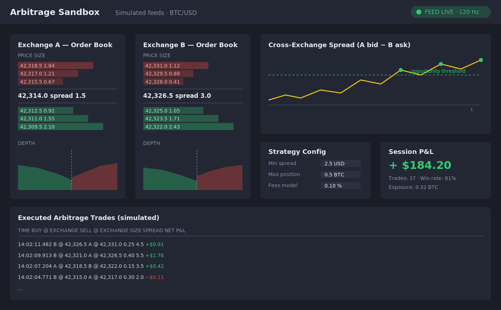

4. **Group expense splitter with settlement engine** — C++ service computes optimal debt settlement across groups in real time; receipts and balances in Firebase; rule/currency configuration tool. *References:*
   - [Splitwise](https://www.splitwise.com/)
   - [Splitwise settle-up tutorial (YouTube)](https://www.youtube.com/watch?v=tOvQ1nPe69I)
5. **Fraud detection & monitoring sandbox** — simulated transaction streams scanned in real time by a C++ rules/anomaly engine; analyst dashboard with alert queue. *References:*
   - [Stripe Radar](https://stripe.com/radar)
   - [Stripe Radar analytics (docs)](https://docs.stripe.com/radar/analytics)
   - [Feedzai](https://www.feedzai.com/)

### Core Tech Requirements per Fintech Example

Legend: ✅ Applies directly | 🔶 Applies with domain adaptation | 🔵 Optional | ❌ Not needed | ⏭️ Second trimester

| Core Tech Requirement | 1. Trading Simulator | 2. Budget Tracker | 3. Arbitrage Sandbox | 4. Expense Splitter | 5. Fraud Sandbox |
| --- | --- | --- | --- | --- | --- |
| External Database | ✅ | ✅ | ✅ | ✅ | ✅ |
| Authentication ⏭️ | ✅ | ✅ | ✅ | ✅ | ✅ |
| Analytics ⏭️ | ✅ | ✅ | ✅ | ✅ | ✅ |
| Real-time C++ Simulation Loop and/or C++ Performant Service | ✅ | ✅ | ✅ | ✅ | ✅ |
| Application Communication | ✅ | ✅ | ✅ | ✅ | ✅ |
| Continuous Integration | ✅ | ✅ | ✅ | ✅ | ✅ |
| Data-Driven Architecture | ✅ | ✅ | ✅ | ✅ | ✅ |
| Front-end + Back-end | ✅ | ✅ | ✅ | ✅ | ✅ |
| Custom Tools Development | 🔶 | 🔶 | 🔶 | 🔶 | 🔶 |
| 2D Graphical Output | 🔶 | 🔶 | 🔶 | 🔶 | 🔶 |
| 3D (strong students only) | ❌ | ❌ | ❌ | ❌ | ❌ |
| Networking System | ❌ | ❌ | ❌ | ❌ | ❌ |

### How each requirement applies

*Common to all five:* the C++ performant service (the financial computation engine — the live-feed examples also drive a real-time loop) · Application Communication (UI ↔︎ engine) · Continuous Integration · Front-end + Back-end · Data-Driven Architecture (products, rules, and fees as data) · Authentication ✅ (accounts are central to the category). Extended target: Firebase + a Linux-server seam set up by M2 (full use T2). Deploy/test device: Pixel 9a.

**1. Stock-trading simulator**

*Platform fit:* **Main:** Native mobile + Web browser on mobile — traders check positions on the go (device: Pixel 9a). **Extended:** Firebase (accounts) + Linux server seam set up by M2, full use in T2.

**Front end:** Custom real-time charts (OpenGL ES), order entry & portfolio UI. **Languages:** Web — HTML/JS/CSS + C++→WASM (Emscripten, SDL2/3, OpenGL ES); Native — Kotlin Native Android UI + C++ via JNI (Android Studio); OpenGL ES in a GLSurfaceView where realtime 2D is needed (no SDL on native).

**Back end:** Market feed engine, pricing/portfolio engine, transaction ledger, Firebase accounts. **Languages:** C++.  
**Backend scope:** Local now; Linux server seam set up & basic-tested by M2, full use in T2.

- *Loop and/or service:* the C++ performant service (pricing + portfolio engine) processes a live/replayed market feed tick-by-tick — a real-time loop here too.
- *Data-driven:* instruments, order rules and fee schedules defined as hot-reloadable data — no hard-coded products.
- *2D:* custom-rendered real-time candlestick/line charts (OpenGL ES; no chart libraries).
- *Custom tool (adapted):* market data replay/configuration tool (PC-side authoring).
- *External DB / Analytics ⏭️:* portfolios, leaderboards, trading-behaviour stats.

**2. Personal budget tracker with forecasting**

*Platform fit:* **Main:** Native mobile — expense entry happens in the moment. **Extended:** Firebase + Linux server set up by M2 (full use in T2). **Device:** Pixel 9a.

**Front end:** Expense entry forms, projection charts, category UI. **Languages:** Web — HTML/JS/CSS + C++→WASM (Emscripten, SDL2/3, OpenGL ES); Native — Kotlin Native Android UI + C++ via JNI (Android Studio); OpenGL ES in a GLSurfaceView where realtime 2D is needed (no SDL on native).

**Back end:** Forecast simulation engine, budget ledger, cross-device sync. **Languages:** C++.  
**Backend scope:** Local only.

- *Loop and/or service:* Monte-Carlo-style forward simulation of balances from spending patterns.
- *Data-driven:* instruments, rules and fee schedules defined as hot-reloadable data.
- *2D:* custom chart renderer for projections. *Custom tool (adapted):* category rules and scenario editor.
- *External DB / Analytics ⏭️:* transactions, budgets, cross-device sync.

**3. Crypto/currency arbitrage sandbox**

*Platform fit:* **Main:** Web browser on mobile — WASM dashboard with panels adapted to the phone layout; the PC build is the development vehicle. **Extended:** Firebase + Linux server set up by M2 (full use in T2). **Device:** Pixel 9a.

**Front end:** Multi-panel dashboard, depth charts, strategy config UI (ImGui). **Languages:** Web — HTML/JS/CSS + C++→WASM (Emscripten, SDL2/3, OpenGL ES); Native — Kotlin Native Android UI + C++ via JNI (Android Studio); OpenGL ES in a GLSurfaceView where realtime 2D is needed (no SDL on native).

**Back end:** High-frequency feed engine, order-book maintenance, strategy engine, trade log. **Languages:** C++.  
**Backend scope:** Local now; Linux server seam set up & basic-tested by M2, full use in T2.

- *Loop and/or service:* genuinely high-frequency — simulated exchange feeds at 100+ Hz, order-book maintenance, opportunity detection. Closest fintech match to the raw requirement.
- *Data-driven:* instruments, rules and fee schedules defined as hot-reloadable data.
- *2D:* order-book depth charts and spread visualization. *Custom tool (adapted):* strategy/fees configuration tool.
- *External DB / Analytics ⏭️:* session results, strategy performance history.

**4. Group expense splitter with settlement engine**

*Platform fit:* **Main:** Native mobile + Web browser on mobile — group members join via a link. **Extended:** Firebase + Linux server set up by M2 (full use in T2). **Device:** Pixel 9a.

**Front end:** Group/balance UI, debt-graph visualization, receipts. **Languages:** Web — HTML/JS/CSS + C++→WASM (Emscripten, SDL2/3, OpenGL ES); Native — Kotlin Native Android UI + C++ via JNI (Android Studio); OpenGL ES in a GLSurfaceView where realtime 2D is needed (no SDL on native).

**Back end:** Settlement optimization engine, expense ledger, Firebase groups & auth. **Languages:** C++.  
**Backend scope:** Local only.

- *Loop and/or service:* real-time recomputation of optimal debt settlement graph as expenses change.
- *Data-driven:* instruments, rules and fee schedules defined as hot-reloadable data.
- *2D:* balance/debt-graph visualization. *Custom tool (adapted):* rules and currency configuration.
- *External DB / Analytics ⏭️:* groups, receipts, balances; auth central for membership.

**5. Fraud detection & monitoring sandbox**

*Platform fit:* **Main:** Web browser on mobile + Native PC (analyst ops) — monitoring and alerts on the phone; the dense analyst review desk stays on the PC side. **Extended:** Firebase + Linux server set up by M2 (full use in T2). **Device:** Pixel 9a.

**Front end:** Analyst dashboard, alert queue, anomaly timelines (ImGui). **Languages:** Web — HTML/JS/CSS + C++→WASM (Emscripten, SDL2/3, OpenGL ES); Native — Kotlin Native Android UI + C++ via JNI (Android Studio); OpenGL ES in a GLSurfaceView where realtime 2D is needed (no SDL on native).

**Back end:** Transaction stream scoring engine, rules engine, immutable case log. **Languages:** C++.  
**Backend scope:** Local now; Linux server seam set up & basic-tested by M2, full use in T2.

- *Loop and/or service:* high-frequency transaction stream scored rule-by-rule in real time — a direct fit.
- *Data-driven:* fraud rules and thresholds as data. *Custom tool (adapted):* rule editor + case dashboard.
- *2D:* anomaly timelines and live metric rendering.
- *Import / alerts / security:* CSV replay of historical data; alert queue; input validation and data protection.

### Goals per Example

The detailed goals below are the **CS track**: G1–G3 ⭐ are the common goals (fixed for all categories); the other 3 are picked from the Fintech pool in the CS Goals Pool (`milestone-goals-pool-per-category.md`; G1–G3 ⭐ common, G4+ picks). At the end of each example, the violet **Track goals** box suggests the Design and Art picks and the TEAM notes for that project — deliverables and quality ladders live in the Design, Art and TEAM pool documents.

**1. Stock-trading simulator**

*M1:*

- **M1G1 ⭐ Application Shell, Real-time C++ Simulation Loop, Input & Core Logic**

  **Tech & dependencies**
  - **Tech:** **Web build:** SDL2/3 shell with a fixed-timestep C++17/20 loop that consumes market ticks and routes order-entry input; CMake, Git. **Native build:** Android Studio (Kotlin Native Android UI + the C++ engine via JNI); OpenGL ES drawn in a GLSurfaceView where realtime 2D is needed — no SDL on native, some screens are pure Native UI.
  - **Prerequisites:** None — foundation of this project.
  - **Feeds into:** M1G4 (feed engine runs on its tick), M1G11 (orders processed in the loop); every other goal.
- **M1G2 ⭐ Data-Driven Architecture of Core Objects / Entity System**

  **Tech & dependencies**
  - **Tech:** Instruments, orders and portfolios defined as JSON data (nlohmann/json) with hot-reloadable instrument lists and market parameters.
  - **Prerequisites:** M1G1 (shell & loop).
  - **Feeds into:** M1G11 (order/portfolio model), M2G2 (replay/config editor edits this data), M2G7 (ledger records these objects).
- **M1G3 ⭐ Debugging, Profiling, Stress Test & CI**

  **Tech & dependencies**
  - **Tech:** ImGui overlay showing tick throughput and frame time, Tracy profiling of the tick→chart path, Catch2 tests on pricing math, stress replay at accelerated speed, GitHub Actions Windows+Linux.
  - **Prerequisites:** M1G1 (loop to instrument).
  - **Feeds into:** M2G3 (CI advanced); safety net for M1G4 and M1G11.
- **M1G4 Real-time Data Feed Engine**

  **Tech & dependencies**
  - **Tech:** Producer/consumer threads pushing live or CSV-replayed market ticks through a lock-free ring buffer into the simulation loop.
  - **Prerequisites:** M1G1 (fixed-timestep loop as consumer).
  - **Feeds into:** M1G5 (charts draw its ticks), M1G11 (orders fill against its prices), M2G4.
- **M1G5 Custom 2D Chart Rendering**

  **Tech & dependencies**
  - **Tech:** **Web build:** Candlestick/line charts rendered from scratch with OpenGL/SDL2/3 and FreeType axis labels — no chart libraries; compiled to WASM via Emscripten for the mobile-web front-end. **Native build:** Android Studio (Kotlin Native Android UI + the C++ engine via JNI); OpenGL ES drawn in a GLSurfaceView where realtime 2D is needed — no SDL on native, some screens are pure Native UI.
  - **Prerequisites:** M1G1 (render loop); consumes M1G4 ticks.
  - **Feeds into:** M2G4 (advanced charting builds on this renderer).
- **M1G11 Order Processing Engine**

  **Tech & dependencies**
  - **Tech:** Order validation and matching against the simulated market with fills priced in fixed-point money math, plus a per-order event log.
  - **Prerequisites:** M1G4 (prices) + M1G2 (order/portfolio data model).
  - **Feeds into:** M2G7 (every fill becomes a ledger entry), M2G8 (portfolio results for leaderboards).

*M2:*

- **M2G1 ⭐ Architecture — Optimization & Platform Validation**

  **Tech & dependencies**
  - **Tech:** **Web build:** Tracy profiling of tick-to-chart latency, ASan on MSVC, feed/render threading (std::thread); Emscripten web build validated in a mobile browser. **Native build:** Android Studio (Kotlin Native Android UI + the C++ engine via JNI); OpenGL ES drawn in a GLSurfaceView where realtime 2D is needed — no SDL on native, some screens are pure Native UI.
  - **Prerequisites:** All M1 goals (hardens the M1 feed→order→chart pipeline).
  - **Feeds into:** M2G4 (GPU charting headroom), M2G8 (stable client for sync).
- **M2G2 ⭐ Content Editor — Core**

  **Tech & dependencies**
  - **Tech:** Market data replay/configuration tool — ImGui editor to pick historical datasets, set replay speed and volatility, and save scenarios as JSON with an undo/redo command stack.
  - **Libraries/Software:** Dear ImGui, nlohmann/json
  - **Prerequisites:** M1G2 (data model) + M1G4 (replay source it configures).
  - **Feeds into:** Demo market scenarios for M2G4 and the showcase.
- **M2G3 ⭐ CI — CMake, Code Quality, Build Standards & Packaging**

  **Tech & dependencies**
  - **Tech:** **Web build:** CMake presets, clang-format + clang-tidy, GitHub Actions matrix, packaged Windows build plus Emscripten web bundle. **Native build:** Android Studio (Kotlin Native Android UI + the C++ engine via JNI); OpenGL ES drawn in a GLSurfaceView where realtime 2D is needed — no SDL on native, some screens are pure Native UI.
  - **Prerequisites:** M1G3 (CI foundation).
  - **Feeds into:** Release/showcase builds of every M2 goal.
- **M2G4 Charting — Advanced**

  **Tech & dependencies**
  - **Tech:** **Web build:** GPU-accelerated OpenGL chart rendering with indicators (SMA/EMA, volume), zoom/pan interaction and multi-timeframe views. **Native build:** Android Studio (Kotlin Native Android UI + the C++ engine via JNI); OpenGL ES drawn in a GLSurfaceView where realtime 2D is needed — no SDL on native, some screens are pure Native UI.
  - **Prerequisites:** M1G5 (chart renderer) + M2G1 (optimization).
  - **Feeds into:** Trader-facing showcase UI on desktop and mobile web.
- **M2G7 Ledger & Audit Trail — Complete**

  **Tech & dependencies**
  - **Tech:** Every simulated order/fill recorded double-entry in fixed-point math in an append-only SHA-256-chained log, with portfolio reconciliation reports.
  - **Prerequisites:** M1G11 (order events) + M1G2 (data model).
  - **Feeds into:** M2G8 (verifiable leaderboard results), P&L reporting.
- **M2G8 Firebase — Auth, Sync & Analytics**

  **Tech & dependencies**
  - **Tech:** Firebase Auth accounts, Firestore sync of portfolios and leaderboards (REST from C++, JS SDK on the web front-end), trading-behavior analytics events.
  - **Prerequisites:** M1G2 (data model to sync) + M2G7 (reconciled results worth publishing).
  - **Feeds into:** Leaderboard and analytics showcase.

**Track Goals & Team Composition**

**Recommended composition:** 6 CS + 2 Design + 0 Art (8) — custom charting is a CS+Design surface; conditionals apply.

**Track goals** — suggested Design/Art picks and TEAM notes for this example; deliverables & quality ladders live in the Design, Art and TEAM pool documents.

- **Design M1:**:
  - M1D1 ⭐ (Features DD: learn/decide goals, virtual-money disclaimers)
  - M1D2 Prototype (observe → decide → act → review) · prototype in Figma
  - M1D6 Scenario design (calm / volatile / crash markets)
  - M1D3 User Research, Personas & Competitive Analysis
  - M1D11 Art POC (conditional — no artist) — the design-owned art surface (style guide, iconography, UI)
- **Design M2:**:
  - M2D1 ⭐ Features Design Iteration & Showcase Readiness
  - M2D6 Complete workflow polished (fund → trade → report)
  - M2D8 Clarity pass (confirmations, P&L moments, no dark patterns)
  - M2D11 Art Implementation Quality (conditional — no artist) — implemented art aligned with the POC, no placeholders
- **UI/UX M1:**:
  - M1U1 ⭐ UI Standards & Wireframe Baseline — screen-flow map and readability standards; where Design M1D4 is picked, the TU review assesses those wireframes.
  - M1U2 UX Flows & Wireframes
  - M1U3 Accessibility & Readability Foundations
- **UI/UX M2:**:
  - M2U1 ⭐ Functional UI & Usability — Fintech screens (order flow with confirmation on anything money-like)
  - M2U2 ⭐ UX Validation & Final Polished UI
  - M2U3 Menu & HUD Motion Design
  - M2U4 Onboarding & Tutorial Design
- **Art:** 0 artists — the art surface is covered by the M2D11 conditionals, taken as Design goals (see Design M1/M2).
- **TEAM M1:**
  - M1TA1 ⭐ Overall Audio Experience — initial BGM/SFX from the week-5 needs list present and working in the prototype, suitable and correctly triggered for this project.
  - M1TA2 ⭐ Audio Engine Functionality — data-driven audio pipeline (add or replace audio without recompiling) and reliable multi-channel playback.
- **TEAM M2:**
  - M2TA1 ⭐ Overall Audio Experience — Fintech floor (no BGM; ≥5 restrained cues)
  - M2TA2 ⭐ Audio Engine Functionality — audio properties de/serialised and the full playback functionality the build needs (multi-channel; advanced where the project calls for it).
  - M2TP1 ⭐ Final Presentation — 7 min in front of class + instructors: live custom-tools showcase, prototype demo, team post-mortem (wk14)

**2. Personal budget tracker with forecasting**

*M1:*

- **M1G1 ⭐ Application Shell, Real-time C++ Simulation Loop, Input & Core Logic**

  **Tech & dependencies**
  - **Tech:** **Web build:** SDL2/3 shell with a fixed-timestep C++17/20 loop driving forecast simulation steps and in-the-moment expense-entry input; CMake, Git. **Native build:** Android Studio (Kotlin Native Android UI + the C++ engine via JNI); OpenGL ES drawn in a GLSurfaceView where realtime 2D is needed — no SDL on native, some screens are pure Native UI.
  - **Prerequisites:** None — foundation of this project.
  - **Feeds into:** M1G15 (forecast steps run on its tick), M1G9 (input routing); every other goal.
- **M1G2 ⭐ Data-Driven Architecture of Core Objects / Entity System**

  **Tech & dependencies**
  - **Tech:** Accounts, categories, transactions and budget rules as hot-reloadable JSON data objects (nlohmann/json).
  - **Prerequisites:** M1G1 (shell & loop).
  - **Feeds into:** M1G12 (aggregates this data), M1G15 (spending patterns as input), M2G2 (rules/scenario editor), M2G7.
- **M1G3 ⭐ Debugging, Profiling, Stress Test & CI**

  **Tech & dependencies**
  - **Tech:** Catch2 tests on fixed-point money math, Tracy profiling of forecast batches, stress runs with years of synthetic transactions, ImGui debug overlays, GitHub Actions Windows+Linux.
  - **Prerequisites:** M1G1 (loop to instrument).
  - **Feeds into:** M2G3; correctness net for M1G12 and M1G15.
- **M1G9 Financial UI / UX**

  **Tech & dependencies**
  - **Tech:** Touch-friendly expense-entry forms, category tables and budget screens built as custom C++ widgets/ImGui with FreeType text for the native-mobile UI.
  - **Prerequisites:** M1G1 (rendering & input).
  - **Feeds into:** M1G12 (dashboards it displays), M2G16 (surface for insights).
- **M1G12 Statistics & Aggregation Engine**

  **Tech & dependencies**
  - **Tech:** Per-category spending aggregation, monthly balance rollups and streaming percentiles over the transaction history, rendered as custom charts.
  - **Prerequisites:** M1G2 (transaction/category data model).
  - **Feeds into:** M1G15 (spending-pattern inputs), M2G10, M2G16 (insight signals).
- **M1G15 Forecast Engine — Foundation**

  **Tech & dependencies**
  - **Tech:** Monte-Carlo forward simulation of future balances from spending patterns (std::random distributions) with percentile bands for projection charts.
  - **Prerequisites:** M1G2 (data model) + M1G12 (pattern statistics).
  - **Feeds into:** M2G10 (scenarios & backtesting), projection UI in M1G9.

*M2:*

- **M2G1 ⭐ Architecture — Optimization & Platform Validation**

  **Tech & dependencies**
  - **Tech:** **Web build:** Tracy profiling and threading of Monte-Carlo batches, memory pools, ASan on MSVC; native-mobile target validated via Android emulator/Emscripten. **Native build:** Android Studio (Kotlin Native Android UI + the C++ engine via JNI); OpenGL ES drawn in a GLSurfaceView where realtime 2D is needed — no SDL on native, some screens are pure Native UI.
  - **Prerequisites:** All M1 goals (hardens the M1 codebase).
  - **Feeds into:** M2G10 (bigger simulation batches), mobile deliverable.
- **M2G2 ⭐ Content Editor — Core**

  **Tech & dependencies**
  - **Tech:** Category rules & scenario editor — ImGui tool to define category rules, recurring items and what-if scenarios, saved as JSON with an undo/redo command stack.
  - **Libraries/Software:** Dear ImGui, nlohmann/json
  - **Prerequisites:** M1G2 (rules/data model it edits).
  - **Feeds into:** M2G10 (scenarios it authors are simulated there).
- **M2G3 ⭐ CI — CMake, Code Quality, Build Standards & Packaging**

  **Tech & dependencies**
  - **Tech:** CMake presets, clang-format + clang-tidy, GitHub Actions matrix, packaged mobile-ready build.
  - **Prerequisites:** M1G3 (CI foundation).
  - **Feeds into:** Release/showcase builds of every M2 goal.
- **M2G7 Ledger & Audit Trail — Complete**

  **Tech & dependencies**
  - **Tech:** Transactions stored as an immutable double-entry ledger in fixed-point math (append-only SHA-256-chained log); edits become correction entries, never overwrites.
  - **Prerequisites:** M1G2 (transaction model) + M1G12 (balances to reconcile).
  - **Feeds into:** M2G10 (backtesting against real history), M2G16 (trustworthy insight data).
- **M2G10 Forecast Engine II**

  **Tech & dependencies**
  - **Tech:** Scenario configs and backtesting of forecasts against ledger history, larger Monte-Carlo batches (std::random) tuned with M2G1 threading.
  - **Prerequisites:** M1G15 (forecast foundation) + M2G7 (historical ledger).
  - **Feeds into:** M2G16 (forecast-based insights), showcase projections.
- **M2G16 Notification & Insight Engine**

  **Tech & dependencies**
  - **Tech:** Budget warnings and spending insights from an in-app event bus, delivered as Firebase Cloud Messaging digests with subscription preferences.
  - **Prerequisites:** M1G12 (statistics) + M2G10 (forecast signals).
  - **Feeds into:** Retention-focused showcase demo on mobile.

**Track Goals & Team Composition**

**Recommended composition:** 6 CS + 2 Design + 0 Art (8) — data-viz and UX breadth; no art-production surface.

**Track goals** — suggested Design/Art picks and TEAM notes for this example; deliverables & quality ladders live in the Design, Art and TEAM pool documents.

- **Design M1:**:
  - M1D1 ⭐ (monitor/decide goals)
  - M1D2 Prototype (add expense → see forecast loop) · prototype in Figma
  - M1D4 UX Flows (entry-first ergonomics)
  - M1D3 User Research, Personas & Competitive Analysis
  - M1D11 Art POC (conditional — no artist) — the design-owned art surface (style guide, iconography, UI)
- **Design M2:**:
  - M2D1 ⭐ Features Design Iteration & Showcase Readiness
  - M2D6 Workflow polished (a month's cycle → report)
  - M2D10 Mobile ergonomics (one-handed entry)
  - M2D11 Art Implementation Quality (conditional — no artist) — implemented art aligned with the POC, no placeholders
- **UI/UX M1:**:
  - M1U1 ⭐ UI Standards & Wireframe Baseline — screen-flow map and readability standards; where Design M1D4 is picked, the TU review assesses those wireframes.
  - M1U2 UX Flows & Wireframes
  - M1U3 Accessibility & Readability Foundations
- **UI/UX M2:**:
  - M2U1 ⭐ Functional UI & Usability — Fintech screens
  - M2U2 ⭐ UX Validation & Final Polished UI
  - M2U3 Menu & HUD Motion Design
  - M2U4 Onboarding & Tutorial Design
- **Art:** 0 artists — the art surface is covered by the M2D11 conditionals, taken as Design goals (see Design M1/M2).
- **TEAM M1:**
  - M1TA1 ⭐ Overall Audio Experience — initial BGM/SFX from the week-5 needs list present and working in the prototype, suitable and correctly triggered for this project.
  - M1TA2 ⭐ Audio Engine Functionality — data-driven audio pipeline (add or replace audio without recompiling) and reliable multi-channel playback.
- **TEAM M2:**
  - M2TA1 ⭐ Overall Audio Experience — Fintech floor
  - M2TA2 ⭐ Audio Engine Functionality — audio properties de/serialised and the full playback functionality the build needs (multi-channel; advanced where the project calls for it).
  - M2TP1 ⭐ Final Presentation — 7 min in front of class + instructors: live custom-tools showcase, prototype demo, team post-mortem (wk14)

**3. Crypto/currency arbitrage sandbox**

*M1:*

- **M1G1 ⭐ Application Shell, Real-time C++ Simulation Loop, Input & Core Logic**

  **Tech & dependencies**
  - **Tech:** **Web build:** SDL2/3 shell with a fixed-timestep C++17/20 loop ticking simulated exchange feeds at 100+ Hz and routing dashboard input; CMake, Git.
  - **Prerequisites:** None — foundation of this project.
  - **Feeds into:** M1G4 (feeds run on its tick), opportunity detection; every other goal.
- **M1G2 ⭐ Data-Driven Architecture of Core Objects / Entity System**

  **Tech & dependencies**
  - **Tech:** Venues, trading pairs, fee schedules and strategy parameters as hot-reloadable JSON data objects (nlohmann/json).
  - **Prerequisites:** M1G1 (shell & loop).
  - **Feeds into:** M1G7 (ledger records these entities), M2G2 (strategy/fees editor edits this data).
- **M1G3 ⭐ Debugging, Profiling, Stress Test & CI**

  **Tech & dependencies**
  - **Tech:** ImGui throughput/latency overlays, Tracy profiling of the feed path, Catch2 tests, stress runs at 10× tick rate, GitHub Actions Windows+Linux.
  - **Prerequisites:** M1G1 (loop to instrument).
  - **Feeds into:** M2G9 (baseline numbers for scaling), M2G3.
- **M1G4 Real-time Data Feed Engine (high-frequency)**

  **Tech & dependencies**
  - **Tech:** Multi-venue simulated exchange feeds at 100+ Hz via producer/consumer threads and lock-free ring buffers, maintaining a live order book per venue.
  - **Prerequisites:** M1G1 (high-frequency loop).
  - **Feeds into:** M1G5 (depth charts), opportunity detection, M2G9 (the hot path to scale).
- **M1G5 Custom 2D Chart Rendering (depth)**

  **Tech & dependencies**
  - **Tech:** **Web build:** Order-book depth charts and spread visualization rendered from scratch with OpenGL/GLSL and FreeType labels, redrawn incrementally at feed rate for the ImGui multi-panel dashboard.
  - **Prerequisites:** M1G1 (render loop) + M1G4 (order-book data).
  - **Feeds into:** M2G6 (live preview in the strategy editor), showcase dashboard.
- **M1G7 Transaction Ledger — Foundation**

  **Tech & dependencies**
  - **Tech:** Double-entry trade log in fixed-point money math with per-venue fees, stored append-only (SQLite or JSON log).
  - **Prerequisites:** M1G2 (venue/trade data model).
  - **Feeds into:** M2G7 (complete audit trail), honest P&L verification per strategy.

*M2:*

- **M2G1 ⭐ Architecture — Optimization & Platform Validation**

  **Tech & dependencies**
  - **Tech:** Tracy profiling of the feed→order-book→detection hot path, ASan on MSVC, per-venue threading, memory pools; native-PC build validated.
  - **Prerequisites:** All M1 goals (hardens the M1 codebase).
  - **Feeds into:** M2G9 (scale work starts from these measurements).
- **M2G2 ⭐ Content Editor — Core**

  **Tech & dependencies**
  - **Tech:** Strategy/fees configuration tool — ImGui editor for strategy parameters and per-venue fee schedules with JSON round-trip and an undo/redo command stack.
  - **Libraries/Software:** Dear ImGui, nlohmann/json
  - **Prerequisites:** M1G2 (strategy/fee data model).
  - **Feeds into:** M2G6 (advanced editor extends this core).
- **M2G3 ⭐ CI — CMake, Code Quality, Build Standards & Packaging**

  **Tech & dependencies**
  - **Tech:** CMake presets, clang-format + clang-tidy, GitHub Actions matrix, packaged native-PC dashboard build.
  - **Prerequisites:** M1G3 (CI foundation).
  - **Feeds into:** Release/showcase builds of every M2 goal.
- **M2G6 Strategy Editor — Advanced**

  **Tech & dependencies**
  - **Tech:** ImGui advanced widgets with drag-drop strategy composition, live preview bound to replayed feeds, and deep undo/redo.
  - **Prerequisites:** M2G2 (editor core) + M1G4 (replayed feeds for preview).
  - **Feeds into:** Strategy-authoring showcase, M2G7 (strategies whose P&L the ledger verifies).
- **M2G7 Ledger & Audit Trail — Complete**

  **Tech & dependencies**
  - **Tech:** Full SHA-256-chained trade log with per-venue fee accounting and reconciliation reports for honest strategy P&L.
  - **Prerequisites:** M1G7 (ledger foundation).
  - **Feeds into:** Credible strategy-performance history, session results for the showcase.
- **M2G9 Engine II — High-Frequency Scale**

  **Tech & dependencies**
  - **Tech:** SIMD, memory pools, cache-friendly order-book layouts and multithreaded venues pushing the simulated feeds well beyond 100 Hz.
  - **Prerequisites:** M2G1 (optimization) + M1G3 (profiling baselines).
  - **Feeds into:** High-frequency scale demo — the showcase centerpiece.

**Track Goals & Team Composition**

**Recommended composition:** 6 CS + 2 Design + 0 Art (8) — order-book visualization is custom rendering, not asset production.

**Track goals** — suggested Design/Art picks and TEAM notes for this example; deliverables & quality ladders live in the Design, Art and TEAM pool documents.

- **Design M1:**:
  - M1D1 ⭐
  - M1D5 Interaction & Data-Density spec (multi-panel readability)
  - M1D6 Scenario design (spread regimes for demos)
  - M1D2 Core-Loop / Interactive Prototype
  - M1D11 Art POC (conditional — no artist) — the design-owned art surface (style guide, iconography, UI)
- **Design M2:**:
  - M2D1 ⭐ Features Design Iteration & Showcase Readiness
  - M2D6 Complete workflow (configure strategy → run → P&L)
  - M2D8 Clarity pass (alert and opportunity moments)
  - M2D11 Art Implementation Quality (conditional — no artist) — implemented art aligned with the POC, no placeholders
- **UI/UX M1:**:
  - M1U1 ⭐ UI Standards & Wireframe Baseline — screen-flow map and readability standards; where Design M1D4 is picked, the TU review assesses those wireframes.
  - M1U2 UX Flows & Wireframes
  - M1U3 Accessibility & Readability Foundations
- **UI/UX M2:**:
  - M2U1 ⭐ Functional UI & Usability — Fintech screens (ops-side dashboard)
  - M2U2 ⭐ UX Validation & Final Polished UI
  - M2U3 Menu & HUD Motion Design
  - M2U4 Onboarding & Tutorial Design
- **Art:** 0 artists — the art surface is covered by the M2D11 conditionals, taken as Design goals (see Design M1/M2).
- **TEAM M1:**
  - M1TA1 ⭐ Overall Audio Experience — initial BGM/SFX from the week-5 needs list present and working in the prototype, suitable and correctly triggered for this project.
  - M1TA2 ⭐ Audio Engine Functionality — data-driven audio pipeline (add or replace audio without recompiling) and reliable multi-channel playback.
- **TEAM M2:**
  - M2TA1 ⭐ Overall Audio Experience — Fintech floor
  - M2TA2 ⭐ Audio Engine Functionality — audio properties de/serialised and the full playback functionality the build needs (multi-channel; advanced where the project calls for it).
  - M2TP1 ⭐ Final Presentation — 7 min in front of class + instructors: live custom-tools showcase, prototype demo, team post-mortem (wk14)

**4. Group expense splitter with settlement engine**

*M1:*

- **M1G1 ⭐ Application Shell, Real-time C++ Simulation Loop, Input & Core Logic**

  **Tech & dependencies**
  - **Tech:** **Web build:** SDL2/3 shell with a fixed-timestep C++17/20 loop that recomputes the optimal settlement graph in real time as expenses change; CMake, Git. **Native build:** Android Studio (Kotlin Native Android UI + the C++ engine via JNI); OpenGL ES drawn in a GLSurfaceView where realtime 2D is needed — no SDL on native, some screens are pure Native UI.
  - **Prerequisites:** None — foundation of this project.
  - **Feeds into:** M1G6 (settlement math runs in its loop); every other goal.
- **M1G2 ⭐ Data-Driven Architecture of Core Objects / Entity System**

  **Tech & dependencies**
  - **Tech:** Groups, members, expenses, receipts and currencies as hot-reloadable JSON data objects (nlohmann/json).
  - **Prerequisites:** M1G1 (shell & loop).
  - **Feeds into:** M1G6 (entities the math operates on), M1G8 and M1G10, M2G7 (ledger of these objects).
- **M1G3 ⭐ Debugging, Profiling, Stress Test & CI**

  **Tech & dependencies**
  - **Tech:** Catch2 property tests on settlement math, Tracy profiling of graph recomputation, stress with large groups and long expense histories, GitHub Actions Windows+Linux.
  - **Prerequisites:** M1G1 (loop to instrument).
  - **Feeds into:** M2G3; correctness net for M1G6 money math.
- **M1G6 Financial Computation Core (settlement math)**

  **Tech & dependencies**
  - **Tech:** Min-cash-flow debt-settlement graph algorithm in fixed-point money math, exhaustively unit-tested so balances always reconcile.
  - **Prerequisites:** M1G2 (group/expense data model).
  - **Feeds into:** Balance/debt-graph UI, M2G7 (ledger it derives from), M2G13 (multi-currency extension).
- **M1G8 Data-Driven Rules System**

  **Tech & dependencies**
  - **Tech:** Split rules, fees and currencies as schema-validated, hot-reloadable, versioned JSON.
  - **Prerequisites:** M1G2 (data-driven architecture).
  - **Feeds into:** M1G6 (rules parameterize the math), M2G2 (editor edits these rules), M2G13.
- **M1G10 Firebase — Accounts & Sync**

  **Tech & dependencies**
  - **Tech:** Firebase Auth for group membership (members join via link) and Firestore sync of groups, receipts and balances — REST from C++, JS SDK on the web front-end.
  - **Prerequisites:** M1G2 (data model to sync).
  - **Feeds into:** M2G7 (shared append-only ledger), M2G14 (mobile clients sync through it).

*M2:*

- **M2G1 ⭐ Architecture — Optimization & Platform Validation**

  **Tech & dependencies**
  - **Tech:** **Web build:** Tracy profiling of settlement recomputation, ASan on MSVC, memory pools; Emscripten WASM build validated in a mobile browser. **Native build:** Android Studio (Kotlin Native Android UI + the C++ engine via JNI); OpenGL ES drawn in a GLSurfaceView where realtime 2D is needed — no SDL on native, some screens are pure Native UI.
  - **Prerequisites:** All M1 goals (hardens the M1 codebase).
  - **Feeds into:** M2G14 (the port depends on this validation).
- **M2G2 ⭐ Content Editor — Core**

  **Tech & dependencies**
  - **Tech:** Rules & currency configuration tool — editor (ImGui or web front-end) for split rules, currencies and exchange rates as JSON with an undo/redo command stack.
  - **Libraries/Software:** Dear ImGui or HTML/JS/CSS (web variant), nlohmann/json
  - **Prerequisites:** M1G8 (rules format) + M1G2 (data model).
  - **Feeds into:** M2G13 (currency/fee models it authors).
- **M2G3 ⭐ CI — CMake, Code Quality, Build Standards & Packaging**

  **Tech & dependencies**
  - **Tech:** **Web build:** CMake presets, clang-format + clang-tidy, GitHub Actions matrix, packaged Windows build plus Emscripten web bundle. **Native build:** Android Studio (Kotlin Native Android UI + the C++ engine via JNI); OpenGL ES drawn in a GLSurfaceView where realtime 2D is needed — no SDL on native, some screens are pure Native UI.
  - **Prerequisites:** M1G3 (CI foundation).
  - **Feeds into:** Release/showcase builds of every M2 goal, including the M2G14 port.
- **M2G7 Ledger & Audit Trail — Complete**

  **Tech & dependencies**
  - **Tech:** Append-only expense ledger with SHA-256 chaining in fixed-point math — the settlement graph derives from it, recording who changed what, when.
  - **Prerequisites:** M1G6 (settlement math) + M1G2 (expense model).
  - **Feeds into:** M2G13 (currency conversions recorded on-ledger), group-trust showcase via M1G10 sync.
- **M2G13 Rules Engine II (multi-currency)**

  **Tech & dependencies**
  - **Tech:** Multi-currency balances with exchange-rate, fee and tax models applied inside the settlement math, all defined as data.
  - **Prerequisites:** M1G8 (rules system) + M2G2 (editor to author them).
  - **Feeds into:** International-group showcase demo, M2G7 (converted amounts stay auditable).
- **M2G14 Mobile Platform Port**

  **Tech & dependencies**
  - **Tech:** **Web build:** Emscripten → WASM web-on-mobile build (or Android NDK), touch input mapping for expense entry, frame-budget profiling. **Native build:** Android Studio (Kotlin Native Android UI + the C++ engine via JNI); OpenGL ES drawn in a GLSurfaceView where realtime 2D is needed — no SDL on native, some screens are pure Native UI.
  - **Prerequisites:** M2G1 (optimization & platform validation).
  - **Feeds into:** Final deliverable — group members join and settle from their phones.

**Track Goals & Team Composition**

**Recommended composition:** 6 CS + 2 Design + 0 Art (8) — settlement flows and clarity are the design load; minimal art.

**Track goals** — suggested Design/Art picks and TEAM notes for this example; deliverables & quality ladders live in the Design, Art and TEAM pool documents.

- **Design M1:**:
  - M1D1 ⭐
  - M1D2 Prototype (add expense → see settlement update) · prototype in Figma
  - M1D4 UX Flows (group joining, balances at a glance)
  - M1D3 User Research, Personas & Competitive Analysis
  - M1D11 Art POC (conditional — no artist) — the design-owned art surface (style guide, iconography, UI)
- **Design M2:**:
  - M2D1 ⭐ Features Design Iteration & Showcase Readiness
  - M2D6 Workflow polished (a trip → settle-up)
  - M2D10 Mobile ergonomics
  - M2D11 Art Implementation Quality (conditional — no artist) — implemented art aligned with the POC, no placeholders
- **UI/UX M1:**:
  - M1U1 ⭐ UI Standards & Wireframe Baseline — screen-flow map and readability standards; where Design M1D4 is picked, the TU review assesses those wireframes.
  - M1U2 UX Flows & Wireframes
  - M1U3 Accessibility & Readability Foundations
- **UI/UX M2:**:
  - M2U1 ⭐ Functional UI & Usability — Fintech screens
  - M2U2 ⭐ UX Validation & Final Polished UI
  - M2U3 Menu & HUD Motion Design
  - M2U4 Onboarding & Tutorial Design
- **Art:** 0 artists — the art surface is covered by the M2D11 conditionals, taken as Design goals (see Design M1/M2).
- **TEAM M1:**
  - M1TA1 ⭐ Overall Audio Experience — initial BGM/SFX from the week-5 needs list present and working in the prototype, suitable and correctly triggered for this project.
  - M1TA2 ⭐ Audio Engine Functionality — data-driven audio pipeline (add or replace audio without recompiling) and reliable multi-channel playback.
- **TEAM M2:**
  - M2TA1 ⭐ Overall Audio Experience — Fintech floor
  - M2TA2 ⭐ Audio Engine Functionality — audio properties de/serialised and the full playback functionality the build needs (multi-channel; advanced where the project calls for it).
  - M2TP1 ⭐ Final Presentation — 7 min in front of class + instructors: live custom-tools showcase, prototype demo, team post-mortem (wk14)

**5. Fraud detection & monitoring sandbox**

*M1:*

- **M1G1 ⭐ Application Shell, Real-time C++ Simulation Loop, Input & Core Logic**

  **Tech & dependencies**
  - **Tech:** **Web build:** SDL2/3 shell with a fixed-timestep C++17/20 loop scoring the simulated transaction stream rule-by-rule in real time; CMake, Git.
  - **Prerequisites:** None — foundation of this project.
  - **Feeds into:** M1G13 (replay drives this loop), M1G14 (scores trigger alerts); every other goal.
- **M1G2 ⭐ Data-Driven Architecture of Core Objects / Entity System**

  **Tech & dependencies**
  - **Tech:** Fraud rules, thresholds, transactions and cases as hot-reloadable, schema-validated JSON data objects (nlohmann/json).
  - **Prerequisites:** M1G1 (shell & loop).
  - **Feeds into:** Scoring in M1G1's loop, M1G14 (thresholds), M2G2 (rule editor edits this data).
- **M1G3 ⭐ Debugging, Profiling, Stress Test & CI**

  **Tech & dependencies**
  - **Tech:** ImGui overlays for stream throughput and per-rule timings, Tracy profiling, Catch2 tests, stress at extreme transaction rates, GitHub Actions Windows+Linux.
  - **Prerequisites:** M1G1 (loop to instrument).
  - **Feeds into:** M2G15 (test suite builds on this infrastructure), M2G3.
- **M1G13 Data Import / Replay Tools**

  **Tech & dependencies**
  - **Tech:** CSV import of historical transaction data with deterministic seeded replay and playback controls, so any flagged incident can be reproduced exactly.
  - **Prerequisites:** M1G1 (deterministic loop) + M1G3 (debugging hooks).
  - **Feeds into:** M1G14 (alert testing on known data), M2G15 (regression replays).
- **M1G14 Alert & Notification System**

  **Tech & dependencies**
  - **Tech:** Threshold-triggered analyst alert queue on an in-app event bus, with Firebase Cloud Messaging for out-of-app escalation pushes.
  - **Prerequisites:** M1G2 (rules/thresholds) + M1G1 (scoring loop that fires events).
  - **Feeds into:** M2G5 (dashboard's alert queue view), M2G11 (alert history in reports).
- **M1G16 Security Foundations**

  **Tech & dependencies**
  - **Tech:** Input validation on imported transaction data, property-based tests and fuzzing basics on the rules engine, ASan on MSVC, local data protection.
  - **Prerequisites:** M1G3 (test infrastructure) + M1G13 (importer as the attack surface).
  - **Feeds into:** M2G15 (integrity suite extends it), trustworthy case log.

*M2:*

- **M2G1 ⭐ Architecture — Optimization & Platform Validation**

  **Tech & dependencies**
  - **Tech:** Tracy profiling of stream scoring, threading of ingest vs scoring vs dashboard rendering, memory pools, ASan on MSVC; native-PC build validated.
  - **Prerequisites:** All M1 goals (hardens the M1 codebase).
  - **Feeds into:** M2G5 (dashboard stays responsive under full stream load).
- **M2G2 ⭐ Content Editor — Core**

  **Tech & dependencies**
  - **Tech:** Fraud rule editor — ImGui tool for authoring rules and thresholds as JSON with an undo/redo command stack and hot-reload into the live scoring engine.
  - **Libraries/Software:** Dear ImGui, nlohmann/json
  - **Prerequisites:** M1G2 (rule data model).
  - **Feeds into:** M2G5 (rule editing embedded in the analyst dashboard), showcase rule-tuning demo.
- **M2G3 ⭐ CI — CMake, Code Quality, Build Standards & Packaging**

  **Tech & dependencies**
  - **Tech:** CMake presets, clang-format + clang-tidy, GitHub Actions matrix, packaged native-PC analyst build.
  - **Prerequisites:** M1G3 (CI foundation).
  - **Feeds into:** Release/showcase builds of every M2 goal; runs M2G15's suite.
- **M2G5 Custom In-Product GUI System**

  **Tech & dependencies**
  - **Tech:** Analyst dashboard widget system — alert queue, anomaly timelines, live metrics and case views with custom ImGui/FreeType widgets, input routing and layout rules.
  - **Prerequisites:** M1G1 (rendering & input) + M1G14 (alert queue it presents).
  - **Feeds into:** M2G11 (report views), M2G2 (hosts the rule editor), showcase dashboard.
- **M2G11 Reports & Statements**

  **Tech & dependencies**
  - **Tech:** Aggregation queries over the immutable case log with HTML/CSV export of incident reports and custom chart snapshots.
  - **Prerequisites:** M1G14 (alert/case history) + M1G2 (case data model).
  - **Feeds into:** Stakeholder-facing showcase outputs, evidence for M2G15 integrity claims.
- **M2G15 Data Integrity & Testing Suite**

  **Tech & dependencies**
  - **Tech:** Property-based tests on scoring and money math, fuzzing of the CSV importer, and integrity checks on the immutable case log of flagged transactions and analyst decisions.
  - **Prerequisites:** M1G16 (security foundations) + M1G3 (test infrastructure) + M1G13 (replay for regressions).
  - **Feeds into:** Trustworthy showcase results, M2G3 (suite runs in CI).

**Track Goals & Team Composition**

**Recommended composition:** 6 CS + 2 Design + 0 Art (8) — analyst dashboard UX; iconography via Design conditionals.

**Track goals** — suggested Design/Art picks and TEAM notes for this example; deliverables & quality ladders live in the Design, Art and TEAM pool documents.

- **Design M1:**:
  - M1D1 ⭐ (analyst trust & clarity requirements)
  - M1D5 Data-Density spec (alert-queue triage ergonomics)
  - M1D6 Scenario design (replayed fraud patterns)
  - M1D2 Core-Loop / Interactive Prototype
  - M1D11 Art POC (conditional — no artist) — the design-owned art surface (style guide, iconography, UI)
- **Design M2:**:
  - M2D1 ⭐ Features Design Iteration & Showcase Readiness
  - M2D6 Workflow polished (detect → investigate → resolve a case)
  - M2D8 Clarity pass (no false-alarm fatigue)
  - M2D11 Art Implementation Quality (conditional — no artist) — implemented art aligned with the POC, no placeholders
- **UI/UX M1:**:
  - M1U1 ⭐ UI Standards & Wireframe Baseline — screen-flow map and readability standards; where Design M1D4 is picked, the TU review assesses those wireframes.
  - M1U2 UX Flows & Wireframes
  - M1U3 Accessibility & Readability Foundations
- **UI/UX M2:**:
  - M2U1 ⭐ Functional UI & Usability — Fintech screens (analyst dashboard)
  - M2U2 ⭐ UX Validation & Final Polished UI
  - M2U3 Menu & HUD Motion Design
  - M2U4 Onboarding & Tutorial Design
- **Art:** 0 artists — the art surface is covered by the M2D11 conditionals, taken as Design goals (see Design M1/M2).
- **TEAM M1:**
  - M1TA1 ⭐ Overall Audio Experience — initial BGM/SFX from the week-5 needs list present and working in the prototype, suitable and correctly triggered for this project.
  - M1TA2 ⭐ Audio Engine Functionality — data-driven audio pipeline (add or replace audio without recompiling) and reliable multi-channel playback.
- **TEAM M2:**
  - M2TA1 ⭐ Overall Audio Experience — Fintech floor (alert-cue hierarchy)
  - M2TA2 ⭐ Audio Engine Functionality — audio properties de/serialised and the full playback functionality the build needs (multi-channel; advanced where the project calls for it).
  - M2TP1 ⭐ Final Presentation — 7 min in front of class + instructors: live custom-tools showcase, prototype demo, team post-mortem (wk14)